# Tpnote

Message: Désolé du retard, j’ai eu un problème de dernière minute pour le rendre.

```r
library(FactoMineR)
library(factoextra)
```

```r
library(tidyverse)
metabric.data <- read.csv2('./data/METABRIC_RNA_Mutation.csv',header=TRUE,sep=",",
row.names='patient_id')
# supprimer les données de mutation que nous n'allons pas utiliser
genes.data <- metabric.data[,1:519]
# Conversion des colonnes au bon type
genes.data <- type_convert(genes.data)
# Première diminution de dimension par selection des $100$ gènes
#les plus corrélées au score de gravité de Nottingham
corre <- c()
for (i in c(1:489)){
corre <- c(corre,cor(genes.data[,21],genes.data[,i+30])**2)
}
selected <- order(corre,decreasing = TRUE)[1:100]
genes.data <- genes.data[,c(1:30,30+selected)]
```

```r
# Supposons que ton jeu de données est stocké dans une variable appelée "data"
nombre_de_colonnes <- ncol(genes.data)

# Afficher le résultat
print(nombre_de_colonnes)
```

```
[1] 130
```

```r
# Dimensions du jeu de données
dimensions <- dim(genes.data)

# Afficher les dimensions
print(dimensions)  # Renvoie un vecteur où la première valeur est le nombre de lignes et la deuxième le nombre de colonnes
```

```
[1] 1904  130
```

```r
# Variables supplémentaires (identification des colonnes mentionnées)
variables_supplementaires <- genes.data[, c(1, 19, 20, 21, 23, 28)] # Quantitatives
qualitatives_supplementaires <- genes.data[, setdiff(1:30, c(1, 19, 20, 21, 23, 28))] # Qualitatives

# Ajouter les qualitatives à la liste des variables supplémentaires
variables_supp <- cbind(variables_supplementaires, qualitatives_supplementaires)
```

Question 1: On centre et réduit:

```r
# Vérification des noms des colonnes
colnames(genes.data)
```

```
  [1] "age_at_diagnosis"               "type_of_breast_surgery"         "cancer_type"
  [4] "cancer_type_detailed"           "cellularity"                    "chemotherapy"
  [7] "pam50_._claudin.low_subtype"    "cohort"                         "er_status_measured_by_ihc"
 [10] "er_status"                      "neoplasm_histologic_grade"      "her2_status_measured_by_snp6"
 [13] "her2_status"                    "tumor_other_histologic_subtype" "hormone_therapy"
 [16] "inferred_menopausal_state"      "integrative_cluster"            "primary_tumor_laterality"
 [19] "lymph_nodes_examined_positive"  "mutation_count"                 "nottingham_prognostic_index"
 [22] "oncotree_code"                  "overall_survival_months"        "overall_survival"
 [25] "pr_status"                      "radio_therapy"                  "X3.gene_classifier_subtype"
 [28] "tumor_size"                     "tumor_stage"                    "death_from_cancer"
 [31] "aurka"                          "chek1"                          "aph1b"
 [34] "cdk1"                           "bcl2"                           "e2f2"
 [37] "ccne1"                          "cdc25a"                         "mapt"
 [40] "igf1r"                          "gata3"                          "fancd2"
 [43] "ccnb1"                          "slc19a1"                        "runx1"
```

[output cut: 29 more lines]

```r
# Sélectionner les indices des variables quantitatives supplémentaires
quanti.sup <- c(1, 19, 20, 21, 23, 28)

# Sélectionner les indices des variables qualitatives supplémentaires
quali.sup <- c(2:18, 22, 24:27, 29:30)
```

On fait l’acp:

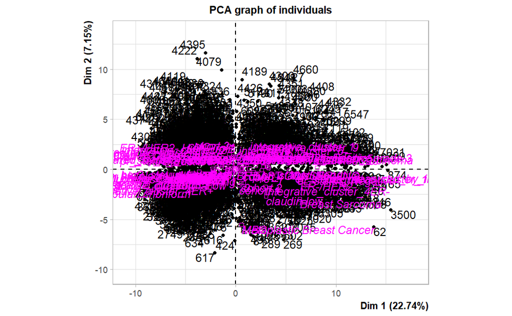

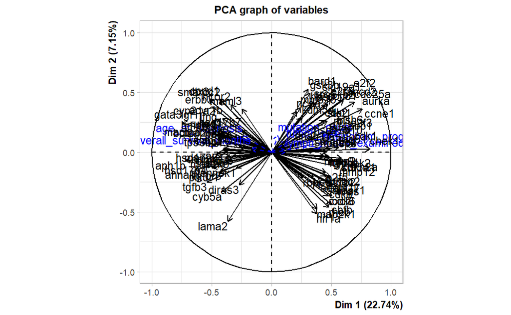

```r
# Appliquer l'ACP avec les variables supplémentaires choisies
res_pca <- PCA(genes.data, ncp = 25, scale.unit = TRUE,
               quanti.sup = quanti.sup,
               quali.sup = quali.sup)
```

```r
dim(genes.data)  # Cela vous donne le nombre de lignes et de colonnes
```

```
[1] 1904  130
```

```r
res_pca$eig
```

```
         eigenvalue percentage of variance cumulative percentage of variance
comp 1   22.7379868             22.7379868                          22.73799
comp 2    7.1488788              7.1488788                          29.88687
comp 3    5.8937293              5.8937293                          35.78059
comp 4    3.5439572              3.5439572                          39.32455
comp 5    3.0305874              3.0305874                          42.35514
comp 6    2.4779017              2.4779017                          44.83304
comp 7    2.1690846              2.1690846                          47.00213
comp 8    2.1167214              2.1167214                          49.11885
comp 9    1.8752415              1.8752415                          50.99409
comp 10   1.7806376              1.7806376                          52.77473
comp 11   1.5619624              1.5619624                          54.33669
comp 12   1.4884054              1.4884054                          55.82509
comp 13   1.3901900              1.3901900                          57.21528
comp 14   1.2784504              1.2784504                          58.49373
comp 15   1.2657476              1.2657476                          59.75948
comp 16   1.1530923              1.1530923                          60.91257
comp 17   1.1223373              1.1223373                          62.03491
comp 18   1.0842317              1.0842317                          63.11914
comp 19   1.0462315              1.0462315                          64.16537
comp 20   1.0183690              1.0183690                          65.18374
comp 21   0.9835208              0.9835208                          66.16726
comp 22   0.9165660              0.9165660                          67.08383
comp 23   0.8842458              0.8842458                          67.96808
comp 24   0.8628686              0.8628686                          68.83095
comp 25   0.8362851              0.8362851                          69.66723
comp 26   0.8132997              0.8132997                          70.48053
comp 27   0.7973047              0.7973047                          71.27783
comp 28   0.7888044              0.7888044                          72.06664
comp 29   0.7559619              0.7559619                          72.82260
comp 30   0.7393188              0.7393188                          73.56192
comp 31   0.7114011              0.7114011                          74.27332
comp 32   0.7023524              0.7023524                          74.97567
comp 33   0.6905076              0.6905076                          75.66618
comp 34   0.6726852              0.6726852                          76.33887
comp 35   0.6530637              0.6530637                          76.99193
comp 36   0.6452028              0.6452028                          77.63713
comp 37   0.6257856              0.6257856                          78.26292
comp 38   0.6185814              0.6185814                          78.88150
comp 39   0.6060936              0.6060936                          79.48759
```

[output cut: 46 more lines]

```
comp 86   0.2281695              0.2281695                          97.58347
comp 87   0.2217705              0.2217705                          97.80524
comp 88   0.2154636              0.2154636                          98.02070
comp 89   0.2030773              0.2030773                          98.22378
comp 90   0.2013985              0.2013985                          98.42518
comp 91   0.1969244              0.1969244                          98.62210
comp 92   0.1872149              0.1872149                          98.80931
comp 93   0.1846269              0.1846269                          98.99394
comp 94   0.1704805              0.1704805                          99.16442
comp 95   0.1574662              0.1574662                          99.32189
comp 96   0.1527297              0.1527297                          99.47462
comp 97   0.1405192              0.1405192                          99.61514
comp 98   0.1378688              0.1378688                          99.75301
comp 99   0.1272561              0.1272561                          99.88026
comp 100  0.1197376              0.1197376                         100.00000
```

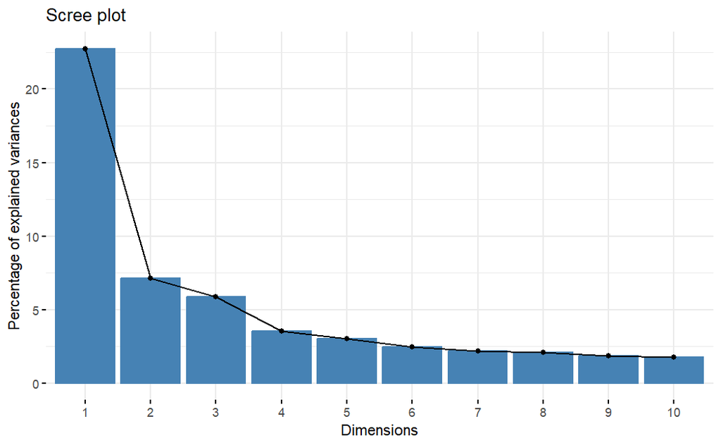

```r
fviz_eig(res_pca)
```

Je garde les 20 première composantes car on atteint une variance cumulée de 65% et qu’ensuite les valeurs propres descendes en dessous de 1 donc pas trop d’intérêt de les garder.

QUESTION 2: Vu que je veux classifier les patiens, je prends les données des 20 premières composantes:

```r
ind_20_dims <- res_pca$ind$coord[, 1:20]
```

```r
# Initialiser un vecteur pour stocker l'inertie
set.seed(123)  # Pour la reproductibilité
wss <- sapply(1:30, function(k) {
  kmeans(ind_20_dims, centers = k, nstart = 25)$tot.withinss
})
```

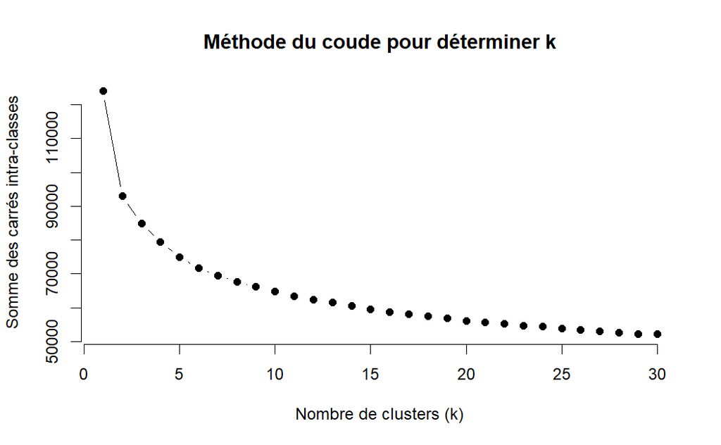

```r
# Tracer le critère du coude
plot(1:30, wss, type = "b", pch = 19, frame = FALSE,
     xlab = "Nombre de clusters (k)",
     ylab = "Somme des carrés intra-classes",
     main = "Méthode du coude pour déterminer k")
```

Je choisis 2 clusters, car premières je remarque que la courbe diminue plus lentement à partir de 2.

```r
kmeans_result <- kmeans(ind_20_dims, centers = 2, nstart = 25)
```

```r
clusters <- kmeans_result$cluster  # Récupérer les clusters attribués
```

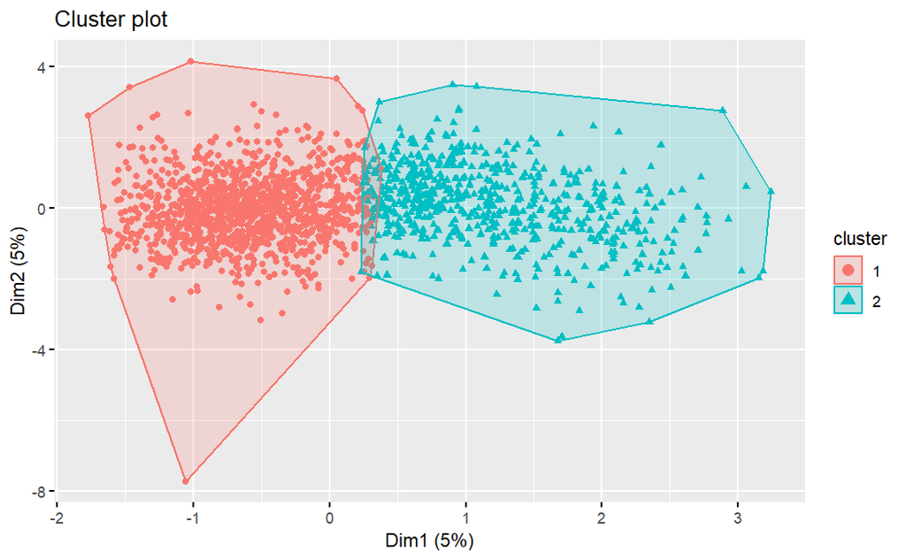

```r
fviz_cluster(kmeans_result, data = ind_20_dims, geom = "point")
```

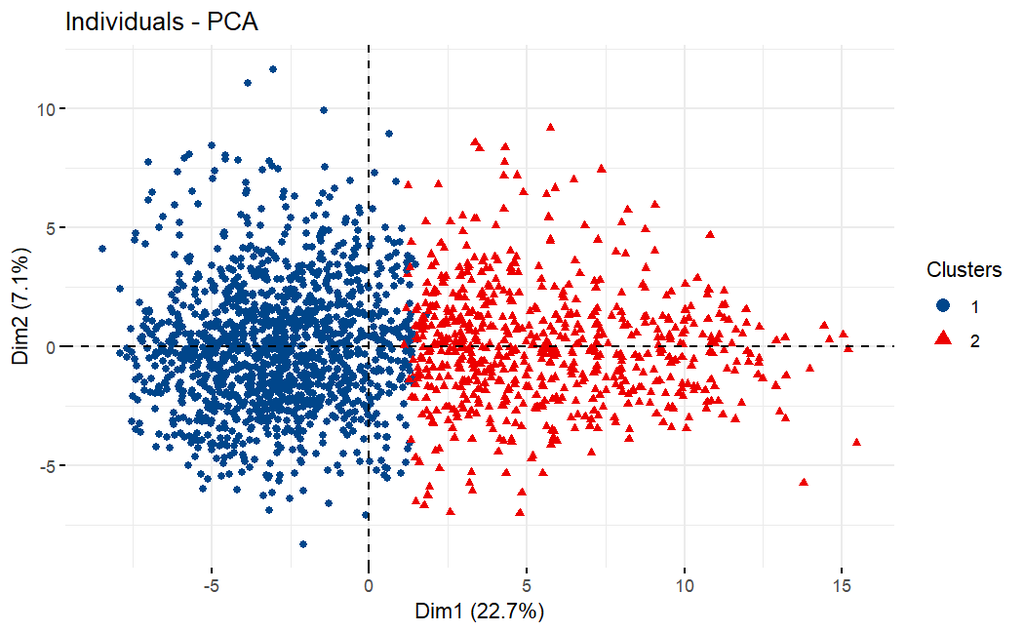

```r
fviz_pca_ind(res_pca,
             axes = c(1, 2),
             col.ind = as.factor(clusters),
             palette = "lancet",
             addEllipses = FALSE,
             legend.title = "Clusters",
             label = "none")
```

On peut s’apercevoir qu’avec les 2 premières dimensions on sépare les 2 clusters cependant y’a une petite zone de confusion entre les 2 types (il y’a des données qui sont vraiment collées sur la frontière), donc utiliser plus de composantes serait plus judicieux.

Question 4:Interprétation des résultats

```r
head(qualitatives_supplementaires)
```

|  | type_of_breast_surgery | cancer_type | cancer_type_detailed | cellularity | chemotherapy | pam50_._claudin.low_subtype | cohort | er_status_measured_by_ihc | er_status | neoplasm_histologic_grade | her2_status_measured_by_snp6 | her2_status | tumor_other_histologic_subtype | hormone_therapy | inferred_menopausal_state | integrative_cluster | primary_tumor_laterality | oncotree_code | overall_survival | pr_status | radio_therapy | X3.gene_classifier_subtype | tumor_stage | death_from_cancer |
| --- | --- | --- | --- | --- | --- | --- | --- | --- | --- | --- | --- | --- | --- | --- | --- | --- | --- | --- | --- | --- | --- | --- | --- | --- |
| 0 | MASTECTOMY | Breast Cancer | Breast Invasive Ductal Carcinoma | NA | 0 | claudin-low | 1 | Positve | Positive | 3 | NEUTRAL | Negative | Ductal/NST | 1 | Post | 4ER+ | Right | IDC | 1 | Negative | 1 | ER-/HER2- | 2 | Living |
| 2 | BREAST CONSERVING | Breast Cancer | Breast Invasive Ductal Carcinoma | High | 0 | LumA | 1 | Positve | Positive | 3 | NEUTRAL | Negative | Ductal/NST | 1 | Pre | 4ER+ | Right | IDC | 1 | Positive | 1 | ER+/HER2- High Prolif | 1 | Living |
| 5 | MASTECTOMY | Breast Cancer | Breast Invasive Ductal Carcinoma | High | 1 | LumB | 1 | Positve | Positive | 2 | NEUTRAL | Negative | Ductal/NST | 1 | Pre | 3 | Right | IDC | 0 | Positive | 0 | NA | 2 | Died of Disease |
| 6 | MASTECTOMY | Breast Cancer | Breast Mixed Ductal and Lobular Carcinoma | Moderate | 1 | LumB | 1 | Positve | Positive | 2 | NEUTRAL | Negative | Mixed | 1 | Pre | 9 | Right | MDLC | 1 | Positive | 1 | NA | 2 | Living |
| 8 | MASTECTOMY | Breast Cancer | Breast Mixed Ductal and Lobular Carcinoma | High | 1 | LumB | 1 | Positve | Positive | 3 | NEUTRAL | Negative | Mixed | 1 | Post | 9 | Right | MDLC | 0 | Positive | 1 | ER+/HER2- High Prolif | 2 | Died of Disease |
| 10 | MASTECTOMY | Breast Cancer | Breast Invasive Ductal Carcinoma | Moderate | 0 | LumB | 1 | Positve | Positive | 3 | NEUTRAL | Negative | Ductal/NST | 1 | Post | 7 | Left | IDC | 0 | Positive | 1 | ER+/HER2- High Prolif | 4 | Died of Disease |

```r
tables_contingence <- list()
# Pour chaque variable dans `qualitatives_supplementaires`
for (var in names(qualitatives_supplementaires)) {
  # Créer une table de contingence entre les clusters et la variable
  table_contingency <- table(clusters, qualitatives_supplementaires[[var]])

  # Ajouter la table à la liste
  tables_contingence[[var]] <- table_contingency

  # Afficher la table de contingence pour chaque variable
  print(paste("Table de contingence pour la variable :", var))
  print(table_contingency)
}
```

```
[1] "Table de contingence pour la variable : type_of_breast_surgery"

clusters BREAST CONSERVING MASTECTOMY
       1               497        748
       2               258        379
[1] "Table de contingence pour la variable : cancer_type"

clusters Breast Cancer Breast Sarcoma
       1          1256              0
       2           647              1
[1] "Table de contingence pour la variable : cancer_type_detailed"

clusters Breast Breast Invasive Ductal Carcinoma Breast Invasive Lobular Carcinoma Breast Invasive Mixed Mucinous Carcinoma
       1     12                              905                               124                                       20
       2      5                              595                                18                                        2

clusters Breast Mixed Ductal and Lobular Carcinoma Metaplastic Breast Cancer
       1                                       186                         1
       2                                        21                         0
[1] "Table de contingence pour la variable : cellularity"

clusters High Low Moderate
       1  568 141      512
       2  371  59      199
[1] "Table de contingence pour la variable : chemotherapy"

clusters    0    1
       1 1132  124
       2  376  272
[1] "Table de contingence pour la variable : pam50_._claudin.low_subtype"

clusters Basal claudin-low Her2 LumA LumB  NC Normal
       1     7          74   54  664  325   6    126
       2   192         125  166   15  136   0     14
[1] "Table de contingence pour la variable : cohort"

clusters   1   2   3   4   5
       1 319 177 503 147 110
       2 162 109 231  89  57
[1] "Table de contingence pour la variable : er_status_measured_by_ihc"
```

[output cut: 69 more lines]

```
[1] "Table de contingence pour la variable : X3.gene_classifier_subtype"

clusters ER-/HER2- ER+/HER2- High Prolif ER+/HER2- Low Prolif HER2+
       1        36                   445                  616    34
       2       254                   158                    3   154
[1] "Table de contingence pour la variable : tumor_stage"

clusters   0   1   2   3   4
       1   2 347 514  55   9
       2   2 128 286  60   0
[1] "Table de contingence pour la variable : death_from_cancer"

clusters Died of Disease Died of Other Causes Living
       1             342                  374    539
       2             280                  106    262
```

On fait mainteannt une boucle pour faire des tests avec chaque table de contingence en nous indiquant s’il y a liaison ou indépendance. On choisit un alpha de 5%

```r
# Effectuer le test du chi-deux pour chaque table de contingence
for (var in names(qualitatives_supplementaires)) {
  # On "refait" une table de contingence à cause de la boucle (on reprends pas ceux d'avant)
  table_contingency <- tables_contingence[[var]]

  # On fait le test du chi-deux
  chi2_test <- chisq.test(table_contingency)

  # calcul p-value
  if (chi2_test$p.value < 0.05) {
    # Si p-value < 0.05, on considère que les variables sont liées
    relation <- "Les variables sont liées"
  } else {
    # Si p-value >= 0.05, on considère que les variables sont indépendantes
    relation <- "Les variables sont indépendantes"
  }

  # Affichage resultats
  print(paste("Test du chi-deux pour la variable :", var))
  print(paste("p-value : ", chi2_test$p.value))
  print(relation)
}
```

```
[1] "Test du chi-deux pour la variable : type_of_breast_surgery"
[1] "p-value :  0.845907703689863"
[1] "Les variables sont indépendantes"
```

```
[1] "Test du chi-deux pour la variable : cancer_type"
[1] "p-value :  0.736072768677679"
[1] "Les variables sont indépendantes"
```

```
[1] "Test du chi-deux pour la variable : cancer_type_detailed"
[1] "p-value :  4.99979610434295e-22"
[1] "Les variables sont liées"
[1] "Test du chi-deux pour la variable : cellularity"
[1] "p-value :  2.30743220541439e-06"
[1] "Les variables sont liées"
[1] "Test du chi-deux pour la variable : chemotherapy"
[1] "p-value :  1.09133616753283e-59"
[1] "Les variables sont liées"
```

```
[1] "Test du chi-deux pour la variable : pam50_._claudin.low_subtype"
[1] "p-value :  4.02026444128072e-199"
[1] "Les variables sont liées"
[1] "Test du chi-deux pour la variable : cohort"
[1] "p-value :  0.221477221594116"
[1] "Les variables sont indépendantes"
[1] "Test du chi-deux pour la variable : er_status_measured_by_ihc"
[1] "p-value :  2.58506812423403e-155"
[1] "Les variables sont liées"
[1] "Test du chi-deux pour la variable : er_status"
[1] "p-value :  6.44876068379996e-184"
[1] "Les variables sont liées"
[1] "Test du chi-deux pour la variable : neoplasm_histologic_grade"
[1] "p-value :  2.88493007462934e-105"
[1] "Les variables sont liées"
```

```
[1] "Test du chi-deux pour la variable : her2_status_measured_by_snp6"
[1] "p-value :  3.73961986841356e-34"
[1] "Les variables sont liées"
[1] "Test du chi-deux pour la variable : her2_status"
[1] "p-value :  6.83315188696026e-50"
[1] "Les variables sont liées"
```

```
[1] "Test du chi-deux pour la variable : tumor_other_histologic_subtype"
[1] "p-value :  1.53593895707266e-27"
[1] "Les variables sont liées"
[1] "Test du chi-deux pour la variable : hormone_therapy"
[1] "p-value :  8.94667176785414e-24"
[1] "Les variables sont liées"
[1] "Test du chi-deux pour la variable : inferred_menopausal_state"
[1] "p-value :  2.3956675694316e-12"
[1] "Les variables sont liées"
[1] "Test du chi-deux pour la variable : integrative_cluster"
[1] "p-value :  2.12798570871443e-214"
[1] "Les variables sont liées"
[1] "Test du chi-deux pour la variable : primary_tumor_laterality"
[1] "p-value :  0.803411808859372"
[1] "Les variables sont indépendantes"
```

```
[1] "Test du chi-deux pour la variable : oncotree_code"
[1] "p-value :  4.99979610434295e-22"
[1] "Les variables sont liées"
[1] "Test du chi-deux pour la variable : overall_survival"
[1] "p-value :  0.321954006344035"
[1] "Les variables sont indépendantes"
[1] "Test du chi-deux pour la variable : pr_status"
[1] "p-value :  4.50890416029854e-86"
[1] "Les variables sont liées"
[1] "Test du chi-deux pour la variable : radio_therapy"
[1] "p-value :  1.03355312539671e-06"
[1] "Les variables sont liées"
[1] "Test du chi-deux pour la variable : X3.gene_classifier_subtype"
[1] "p-value :  5.63940135181774e-194"
[1] "Les variables sont liées"
```

```
[1] "Test du chi-deux pour la variable : tumor_stage"
[1] "p-value :  8.70189640418511e-07"
[1] "Les variables sont liées"
[1] "Test du chi-deux pour la variable : death_from_cancer"
[1] "p-value :  9.57911990890848e-15"
[1] "Les variables sont liées"
```

Interprétation: Voici quelques exemples des variables qui ne sont pas indépendants aux 2 clusters selon le test du chi 2:cancer_type_detailed, cellularity, chemotherapy, her2_status, er_status, hormone_therapy, inferred_menopausal_state, radio_therapy,tumor_stage.

Pour voir des “liens” je regarde les descriptions des variables sur le site.

On peut voir des liens entre les variables qui sont liés aux clusters: Par exemple, la variable er_status (récepteurs d’œstrogène) et her2_status (récepteurs HER2) influencent directement les choix thérapeutiques comme les traitements hormonaux et les thérapies ciblées, ce qui explique leur corrélation avec les clusters. S’ils sont liés aux clusters c’est logiques qu’elles aient un une similarité dans le monde réel de part leurs impacts aux patients.

On peut voir aussi une autre proximité: Les variables cellularity et neoplasm_histologic_grade, indiquent l’agressivité de la tumeur car cellularity est la quantité de cellules tumorales et neoplasm_histologic_grade représente la nature des cellules cancéreuse et leur aggressivité. On pourrait penser que dans le monde réels elles peuvent être liées car certaines natures de cellules peuven être plus nombreuses ou moins nombreuse par exemple. Donc si elles ont une proximité dans la vie réelle c’est pas incohérants qu’elles soient liées en même temps aux 2 clusters.

Question 5: Prédiction de l’indice de Nottingham

En ayant fait des recherches l’indice de Nottingham se base en général sur 3 critère pathologiques majeurs: La grosseur de la tumeur L’état des ganglions lymphatiques. Stade du cancer Je selectionne des variables qui s’en rapproches

```r
# Sélection des variables pertinentes
data_model <- data.frame(
  tumor_size = genes.data$tumor_size,
  lymph_nodes_examined_positive = genes.data$lymph_nodes_examined_positive,
  neoplasm_histologic_grade = genes.data$neoplasm_histologic_grade
)

# On retire les lignes avec des valeurs manquantes
data_model <- na.omit(data_model)

# le modèle linéaire
model <- lm(nottingham_prognostic_index ~ tumor_size + lymph_nodes_examined_positive + neoplasm_histologic_grade, data = genes.data)

# Résumé du modèle
summary(model)
```

```
Call:
lm(formula = nottingham_prognostic_index ~ tumor_size + lymph_nodes_examined_positive +
    neoplasm_histologic_grade, data = genes.data)

Residuals:
    Min      1Q  Median      3Q     Max
-4.0796 -0.3778 -0.3004  0.4378  1.2463

Coefficients:
                               Estimate Std. Error t value Pr(>|t|)
(Intercept)                   1.1696709  0.0484119  24.161  < 2e-16 ***
tumor_size                    0.0061798  0.0008147   7.585 5.28e-14 ***
lymph_nodes_examined_positive 0.1258688  0.0030311  41.526  < 2e-16 ***
neoplasm_histologic_grade     1.0470996  0.0186380  56.181  < 2e-16 ***
---
Signif. codes:  0 ‘***’ 0.001 ‘**’ 0.01 ‘*’ 0.05 ‘.’ 0.1 ‘ ’ 1

Residual standard error: 0.5081 on 1811 degrees of freedom
  (89 observations effacées parce que manquantes)
Multiple R-squared:  0.7751,    Adjusted R-squared:  0.7747
F-statistic:  2081 on 3 and 1811 DF,  p-value: < 2.2e-16
```

```r
# On prédit l'indice de Nottingham avec le modèle
predictions <- predict(model, newdata = data_model)
```